# yutian_analysis

Yutian Luo

12/11/2020

# 2. Verify if this association holds true in this dataset, but also explore associations of all the other covariates mentioned above and draw your own conclusions.

```
    the initial analysis published by FiveThirtyEight showed that income inequality was the main predictor of hate crimes rates.
```

```r
hatecrime_data =
  read.csv("./data/HateCrimes.csv")
```

```r
hatecrime_df =
  hatecrime_data %>%
  janitor::clean_names() %>%
  mutate(
    state = as.factor(state),
    unemployment = as.factor(unemployment),
    urbanization = as.factor(urbanization),
    hate_crimes_per_100k_splc = as.numeric(hate_crimes_per_100k_splc)
  )
```

# why use gini index to represent inequality

…

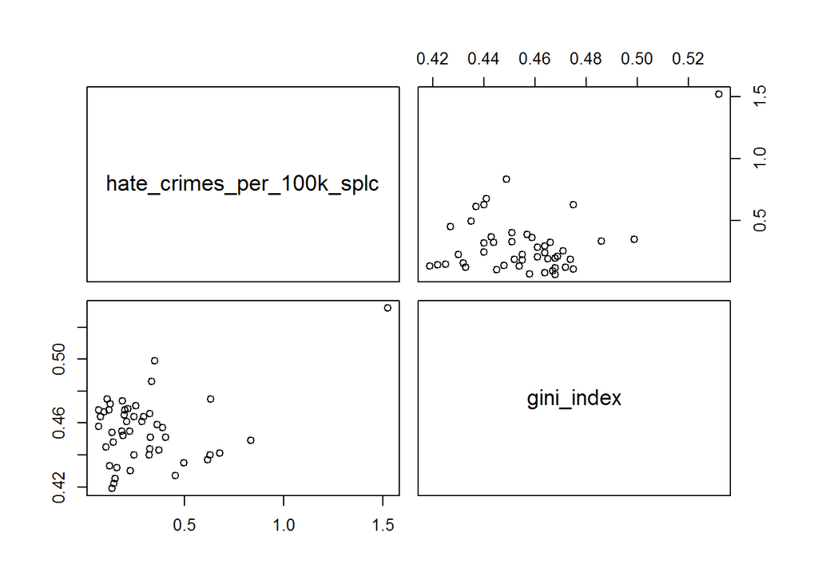

```r
attach(hatecrime_df)

pairs(hate_crimes_per_100k_splc~gini_index)
```

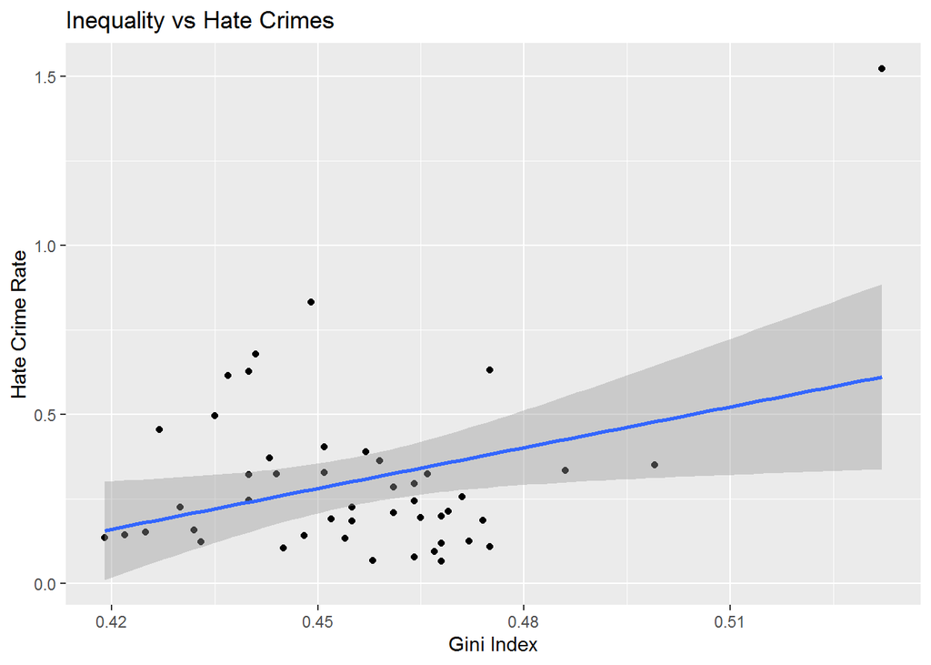

```r
ggplot(hatecrime_df, aes(y = hate_crimes_per_100k_splc, x = gini_index))+
  geom_point()+
  geom_smooth(method="lm", se = TRUE)+
  labs(title = "Inequality vs Hate Crimes")+
  labs(x = "Gini Index", y = "Hate Crime Rate")
```

From our initial association analysis, there is limited association between the two variables.

We furthere analyze by linear method.

```r
# linear method
fit_mod1 =
  lm(hate_crimes_per_100k_splc~gini_index, data = hatecrime_df)
summary(fit_mod1)
```

```
##
## Call:
## lm(formula = hate_crimes_per_100k_splc ~ gini_index, data = hatecrime_df)
##
## Residuals:
##      Min       1Q   Median       3Q      Max
## -0.28669 -0.14565 -0.04991  0.07356  0.91085
##
## Coefficients:
##             Estimate Std. Error t value Pr(>|t|)
## (Intercept)  -1.5275     0.7833  -1.950   0.0574 .
## gini_index    4.0205     1.7177   2.341   0.0237 *
## ---
## Signif. codes:  0 '***' 0.001 '**' 0.01 '*' 0.05 '.' 0.1 ' ' 1
##
## Residual standard error: 0.2412 on 45 degrees of freedom
##   (4 observations deleted due to missingness)
## Multiple R-squared:  0.1085, Adjusted R-squared:  0.08872
## F-statistic: 5.478 on 1 and 45 DF,  p-value: 0.02374
```

```r
# anova
anova(fit_mod1)
```

```
## Analysis of Variance Table
##
## Response: hate_crimes_per_100k_splc
##            Df  Sum Sq Mean Sq F value  Pr(>F)
## gini_index  1 0.31882 0.31882  5.4784 0.02374 *
## Residuals  45 2.61881 0.05820
## ---
## Signif. codes:  0 '***' 0.001 '**' 0.01 '*' 0.05 '.' 0.1 ' ' 1
```

From the t test, we conclude that we are 95% confident that the inequality has a positive linear association with the hate crime rate.

This suggests that the higher inequality is, the higher rate of hate crime will occur.

# futher interpreate

…

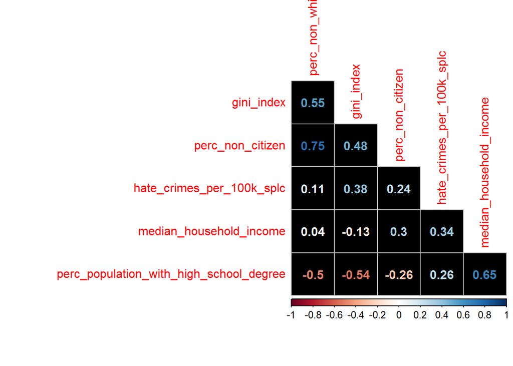

```r
hatecrime_df =
  hatecrime_df %>%
  drop_na()

cor(hatecrime_df[,c(4,5,6,7,8,9)])%>%
  corrplot(method = "number", type = "lower", diag=FALSE, bg = "black", order = "FPC")
```

The other pair of moderate correlation is between inequality and population’s high school degreee percentage; inequality with percent of alien; education with percent of none white; and education with inequality.

# mlr model

Our hypothesis for mlr model: 1. gini index 2. education

# We use correlation matrix to propose for a mlr model in part 4